# ROSA_vitaSPEC_fruits

25 février 2026

# Load & Save data

## Yvalue

## Xvalue

# Cross Validation

## Prep data

## CV

[1] “eau”

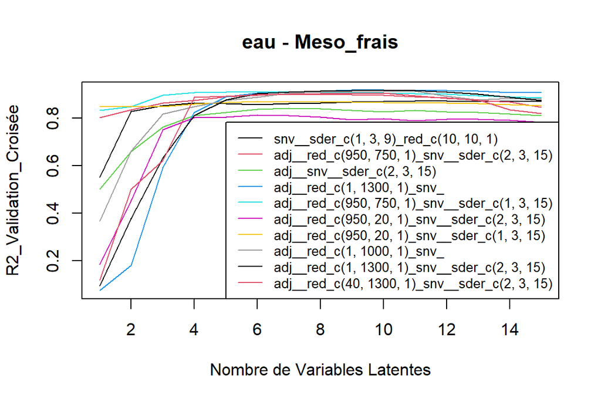

Pré : adj__red_c(1, 1300, 1)*snv*

R2 : 0.07 0.18 0.59 0.83 0.89 0.91 0.91 0.91 0.92 0.92 0.92 0.92 0.92 0.91 0.91

SEP : 9.32 8.77 6.17 4.06 3.2 2.97 2.87 2.82 2.75 2.75 2.77 2.77 2.83 2.93 2.88

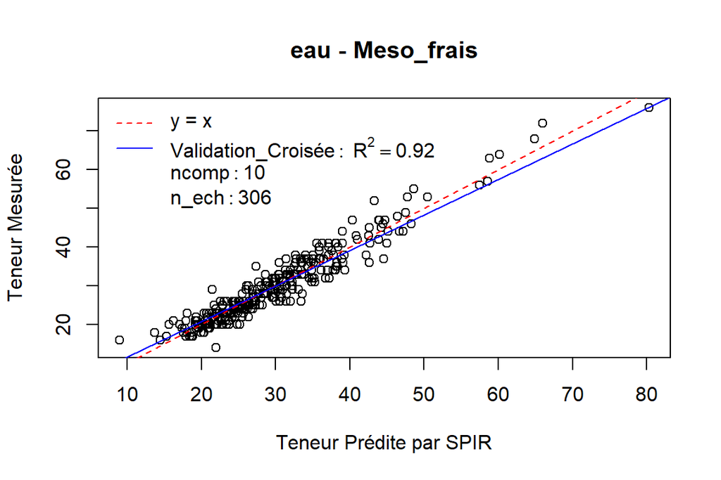

[1] “C14.0”

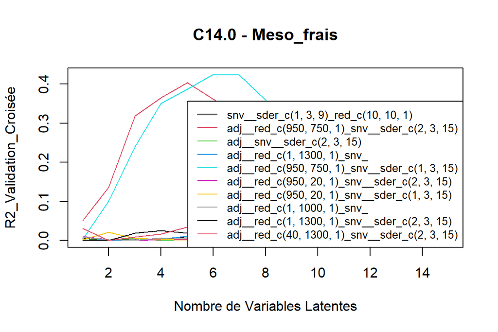

Pré : adj__red_c(950, 750, 1)_snv__sder_c(1, 3, 15)

R2 : 0 0.1 0.24 0.35 0.39 0.42 0.42 0.36 0.28 0.24 0.21 0.17 0.17 0.15 0.14

SEP : 0.36 0.35 0.31 0.29 0.28 0.27 0.27 0.3 0.33 0.35 0.37 0.4 0.4 0.43 0.45

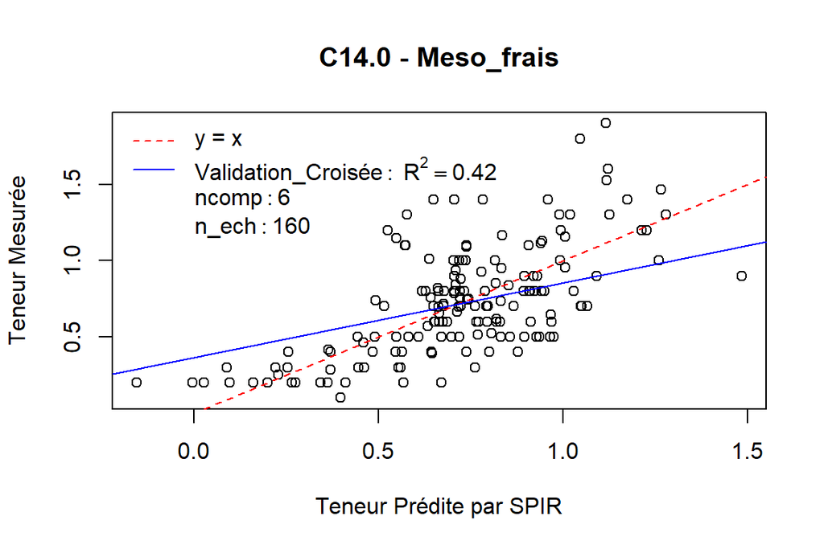

[1] “C16.0”

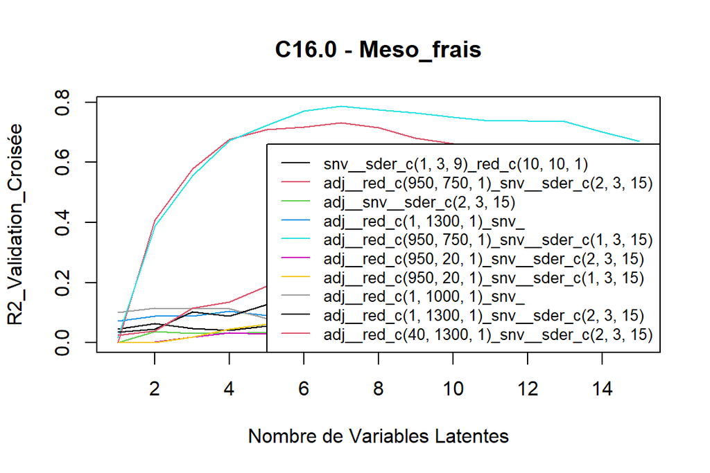

Pré : adj__red_c(950, 750, 1)_snv__sder_c(1, 3, 15)

R2 : 0.02 0.39 0.56 0.67 0.72 0.77 0.79 0.77 0.77 0.75 0.74 0.74 0.73 0.7 0.67

SEP : 5.13 4.08 3.45 2.98 2.74 2.49 2.4 2.48 2.54 2.65 2.73 2.73 2.74 2.97 3.17

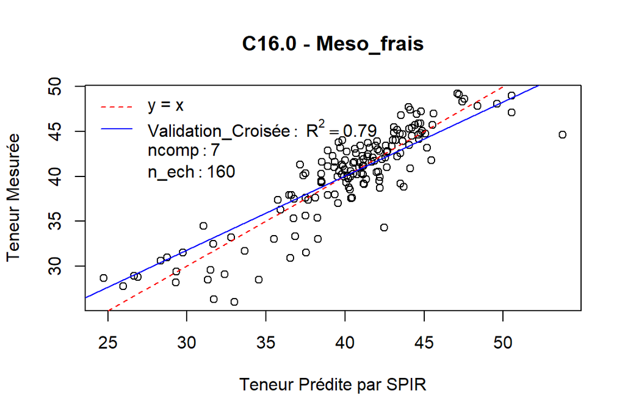

[1] “C18.0”

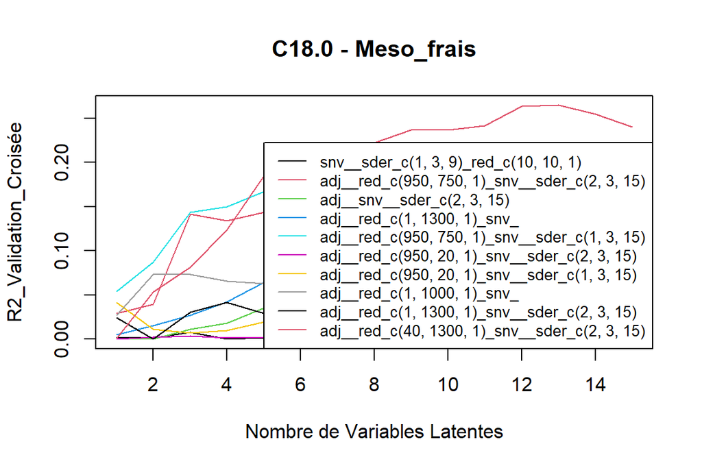

Pré : adj__red_c(40, 1300, 1)_snv__sder_c(2, 3, 15)

R2 : 0 0.05 0.08 0.12 0.18 0.19 0.18 0.22 0.24 0.24 0.24 0.26 0.26 0.25 0.24

SEP : 1.52 1.49 1.46 1.44 1.38 1.39 1.41 1.37 1.37 1.37 1.38 1.37 1.37 1.41 1.45

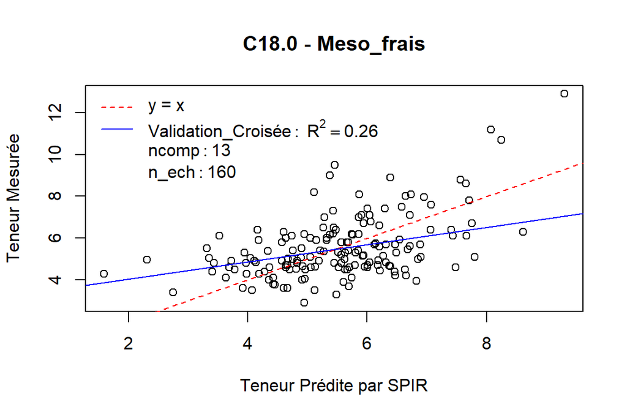

[1] “C18.1n9”

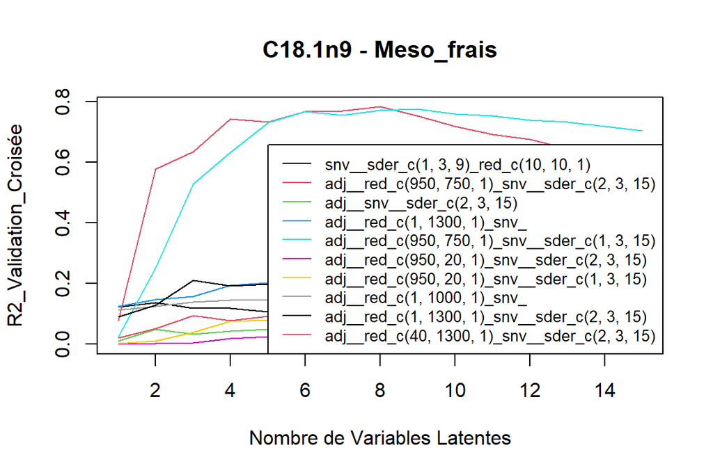

Pré : adj__red_c(950, 750, 1)_snv__sder_c(2, 3, 15)

R2 : 0.08 0.58 0.63 0.74 0.73 0.77 0.77 0.78 0.75 0.72 0.69 0.68 0.65 0.62 0.57

SEP : 5.28 3.56 3.32 2.79 2.87 2.67 2.65 2.58 2.81 3.06 3.24 3.36 3.57 3.78 4.15

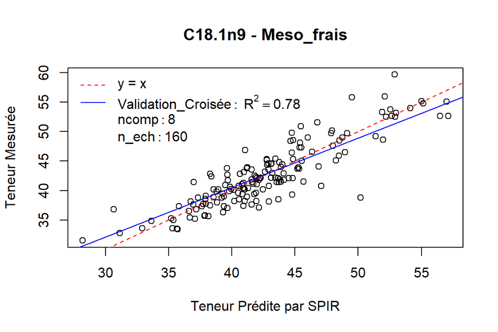

[1] “C18.1n7”

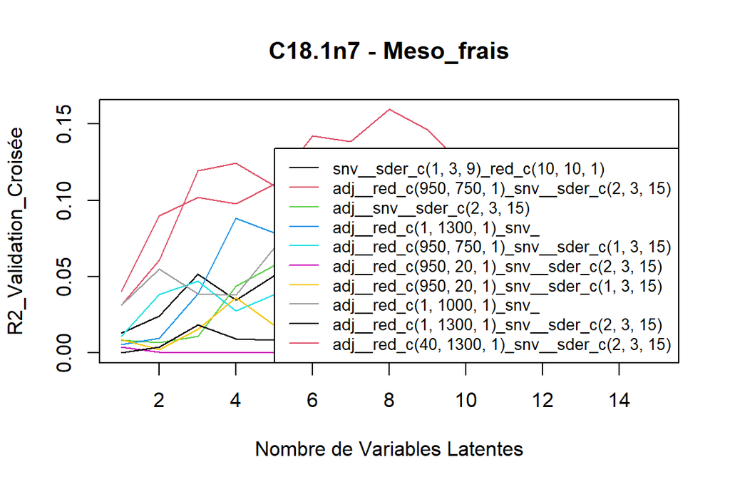

Pré : adj__red_c(40, 1300, 1)_snv__sder_c(2, 3, 15)

R2 : 0.04 0.09 0.1 0.1 0.11 0.14 0.14 0.16 0.15 0.12 0.1 0.11 0.11 0.1 0.08

SEP : 0.63 0.61 0.61 0.62 0.63 0.61 0.62 0.62 0.64 0.68 0.72 0.72 0.76 0.78 0.82

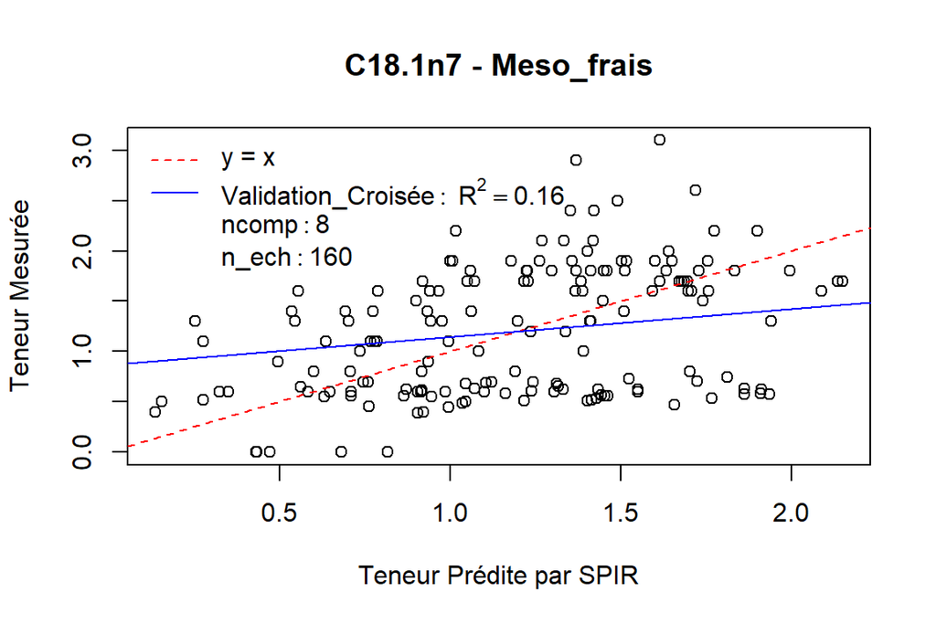

[1] “C18.2”

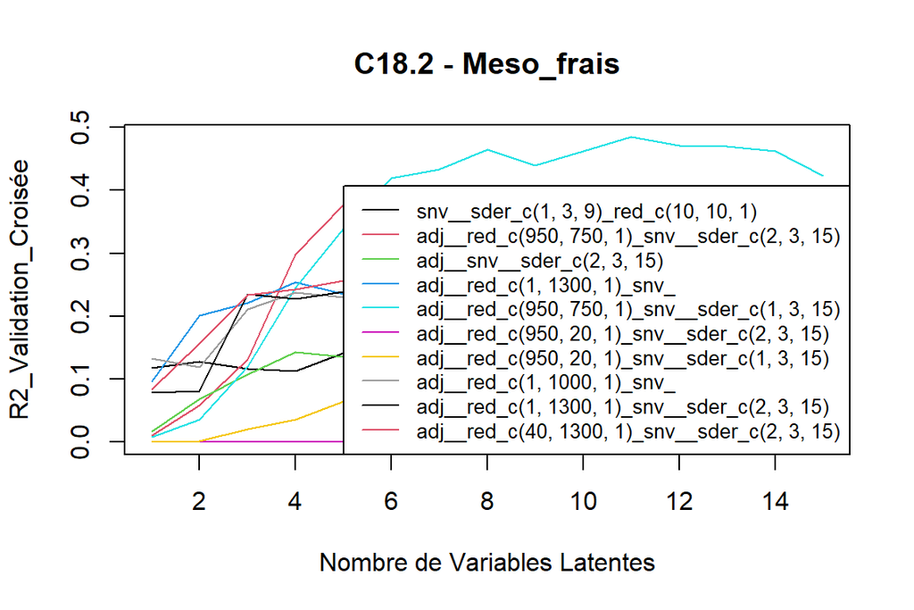

Pré : adj__red_c(950, 750, 1)_snv__sder_c(1, 3, 15)

R2 : 0.01 0.04 0.12 0.25 0.34 0.42 0.43 0.47 0.44 0.46 0.48 0.47 0.47 0.46 0.42

SEP : 1.65 1.63 1.57 1.45 1.35 1.28 1.26 1.23 1.27 1.25 1.22 1.26 1.27 1.32 1.44

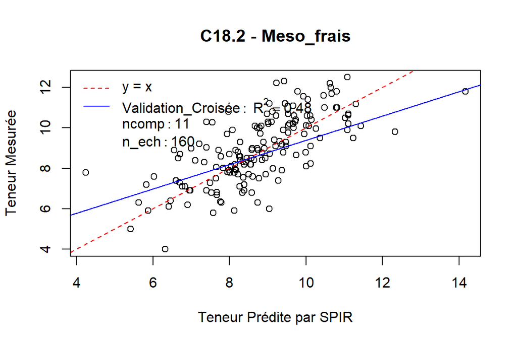

[1] “C18.3”

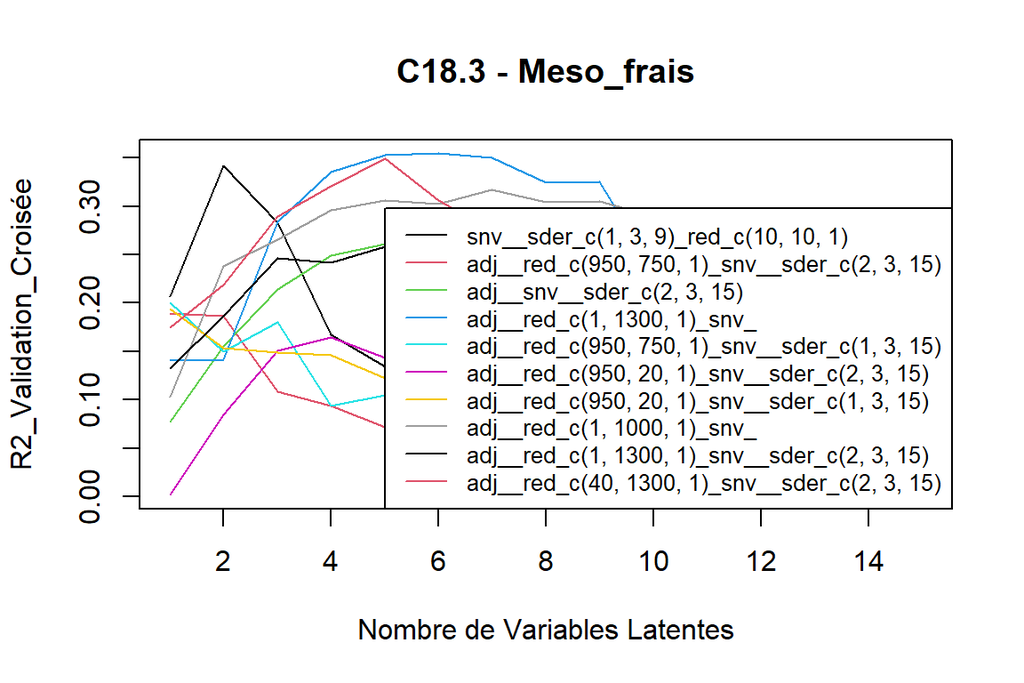

Pré : adj__red_c(1, 1300, 1)*snv*

R2 : 0.14 0.14 0.28 0.34 0.35 0.35 0.35 0.32 0.33 0.23 0.19 0.17 0.15 0.12 0.11

SEP : 0.11 0.11 0.1 0.1 0.09 0.09 0.1 0.1 0.1 0.11 0.11 0.12 0.12 0.13 0.13

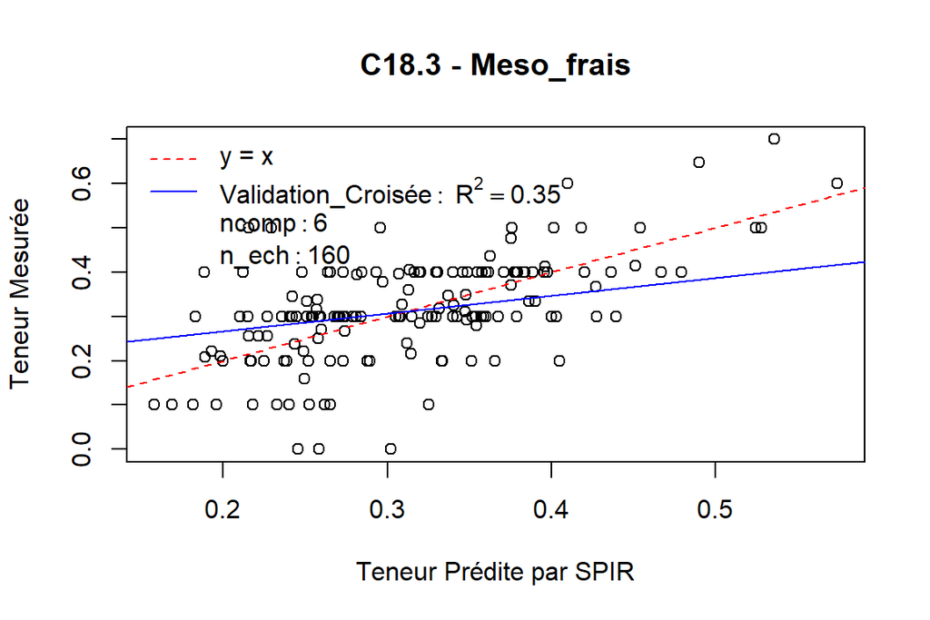

[1] “C20.0”

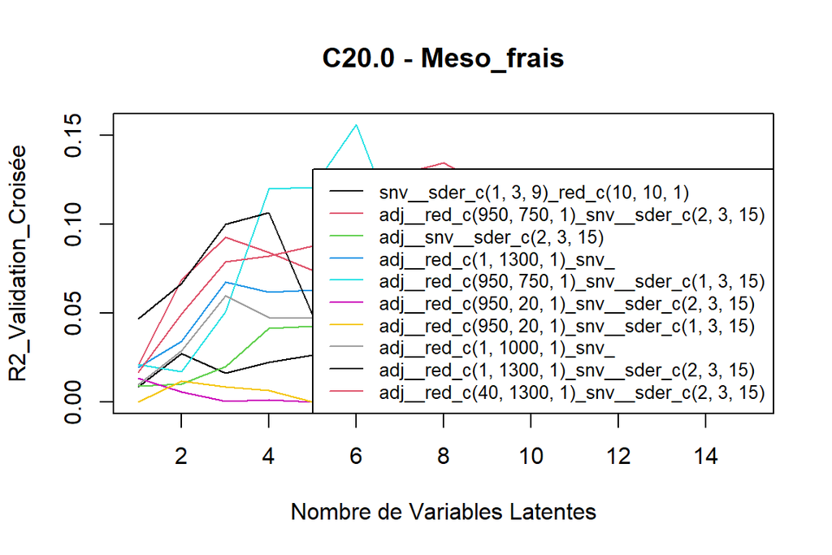

Pré : adj__red_c(950, 750, 1)_snv__sder_c(1, 3, 15)

R2 : 0.02 0.02 0.05 0.12 0.12 0.16 0.09 0.08 0.07 0.06 0.05 0.03 0.02 0.02 0.01

SEP : 0.11 0.11 0.11 0.1 0.1 0.1 0.11 0.11 0.11 0.12 0.12 0.13 0.14 0.14 0.15

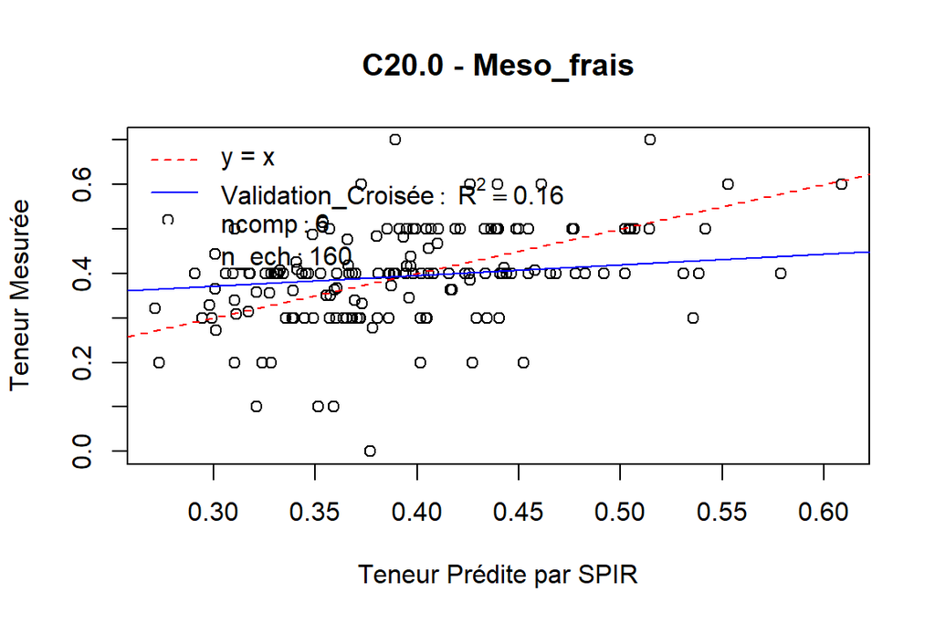

[1] “tlip.MS”

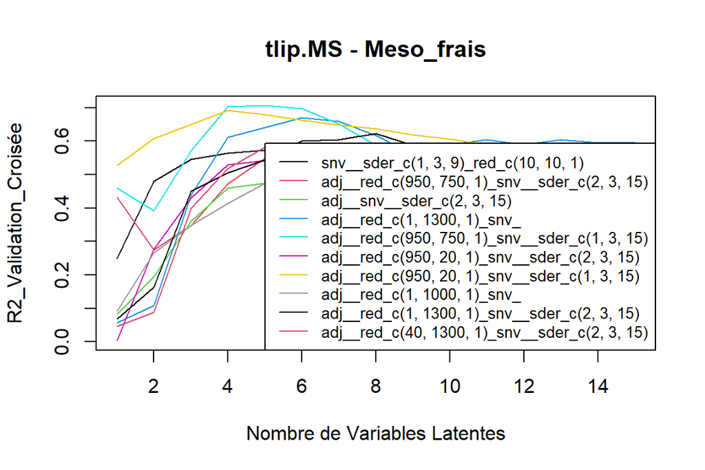

Pré : adj__red_c(950, 750, 1)_snv__sder_c(1, 3, 15)

R2 : 0.46 0.39 0.57 0.7 0.71 0.7 0.65 0.59 0.57 0.53 0.46 0.44 0.42 0.4 0.4

SEP : 3.48 3.71 3.11 2.59 2.57 2.61 2.81 3.05 3.13 3.31 3.6 3.67 3.8 3.88 3.87

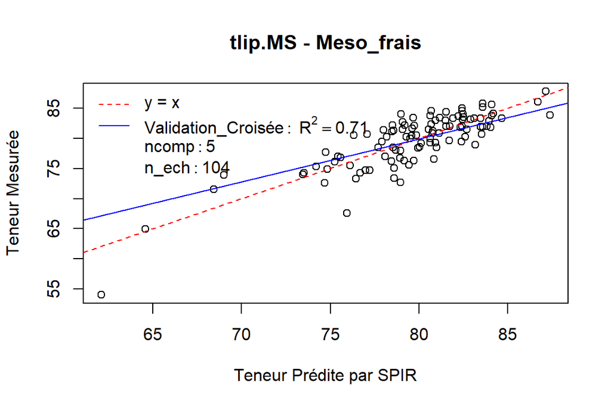

[1] “trans.alpha.carotne”

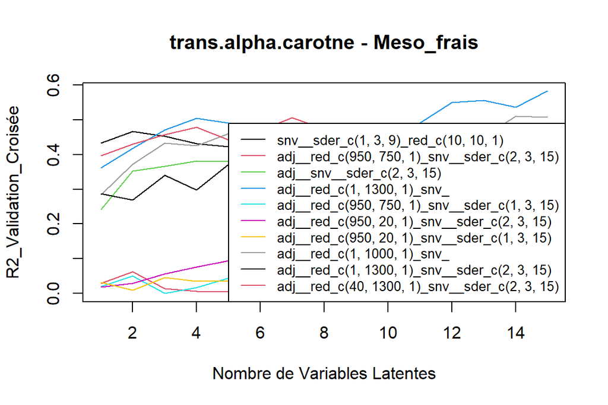

Pré : adj__red_c(1, 1300, 1)*snv*

R2 : 0.36 0.42 0.47 0.5 0.49 0.45 0.46 0.46 0.41 0.48 0.49 0.55 0.56 0.54 0.58

SEP : 296.16 283 270.54 262.83 269.99 283.78 285.22 285.23 304.03 283.52 284.4 261.58 262.46 268.9 252.71

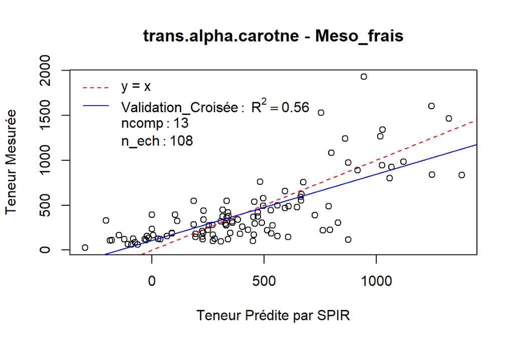

[1] “trans.beta.carotene”

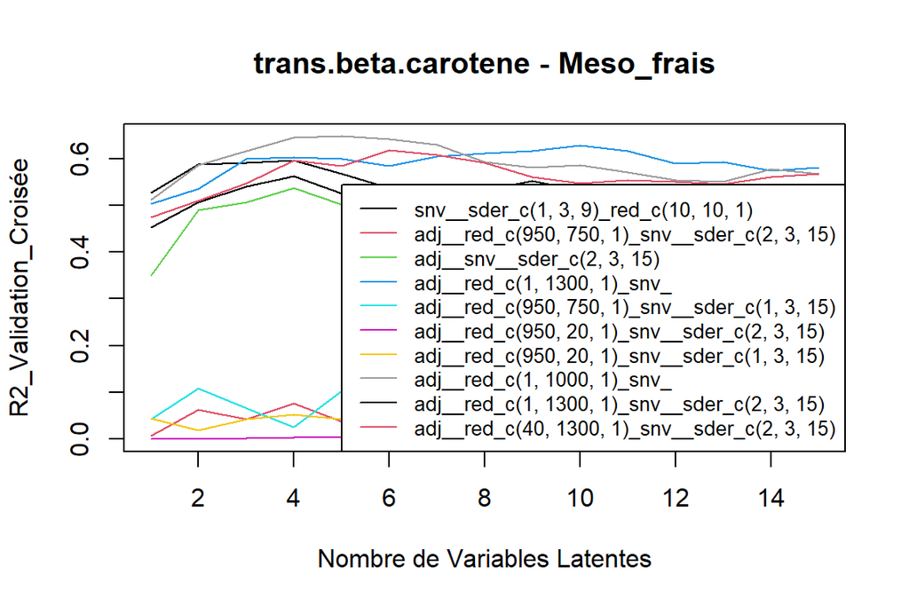

Pré : adj__red_c(1, 1000, 1)*snv*

R2 : 0.51 0.59 0.62 0.65 0.65 0.64 0.63 0.59 0.58 0.59 0.57 0.55 0.55 0.58 0.57

SEP : 246.95 227.36 219.33 210.66 210.09 212.49 216.71 230.47 234.22 234.14 240.09 246.84 248.61 243.11 252.39

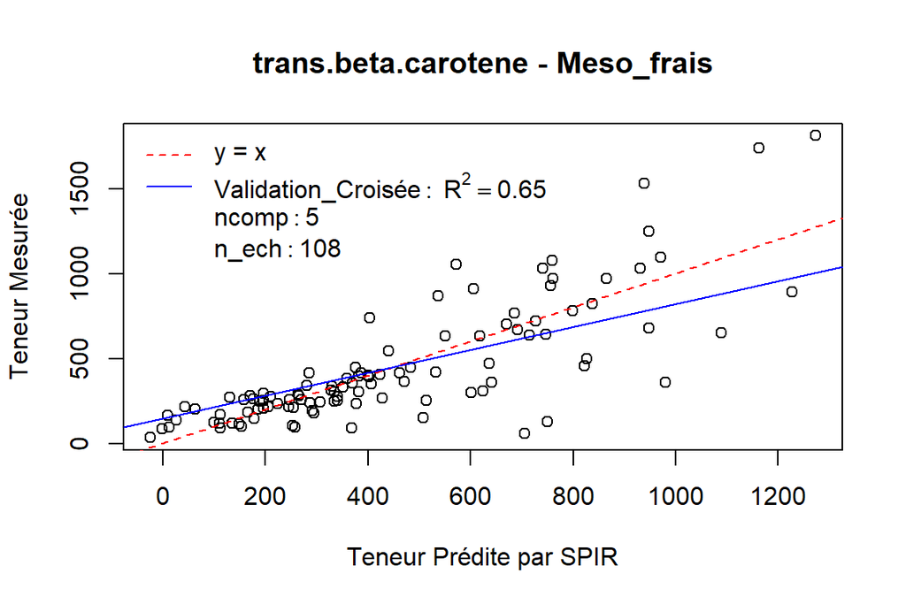

[1] “X13.cis.beta.carotene”

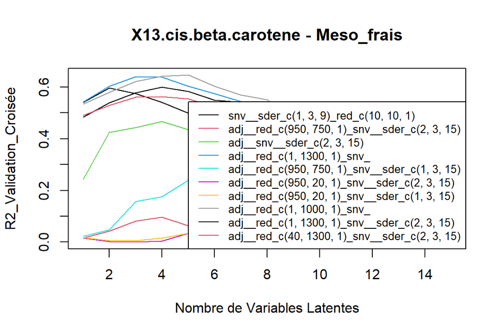

Pré : adj__red_c(1, 1000, 1)*snv*

R2 : 0.53 0.58 0.62 0.64 0.65 0.6 0.57 0.55 0.48 0.48 0.46 0.48 0.48 0.47 0.46

SEP : 24.87 23.7 22.51 21.83 21.68 23.13 24.24 24.84 27.67 27.57 27.66 27.17 27.53 27.96 28.59

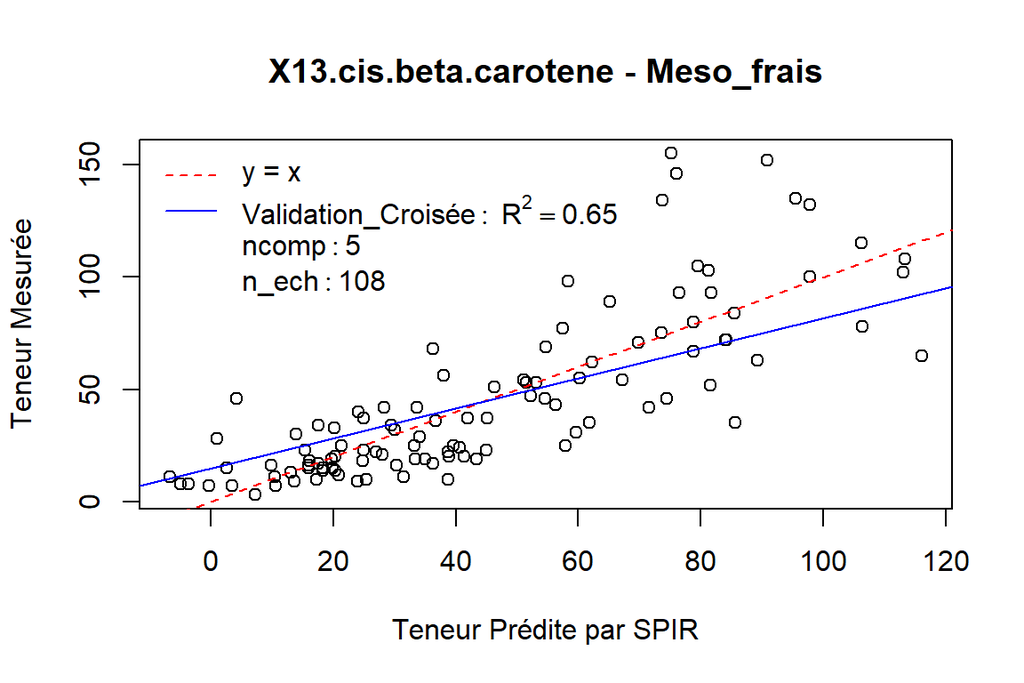

[1] “X9.cis.beta.carotene”

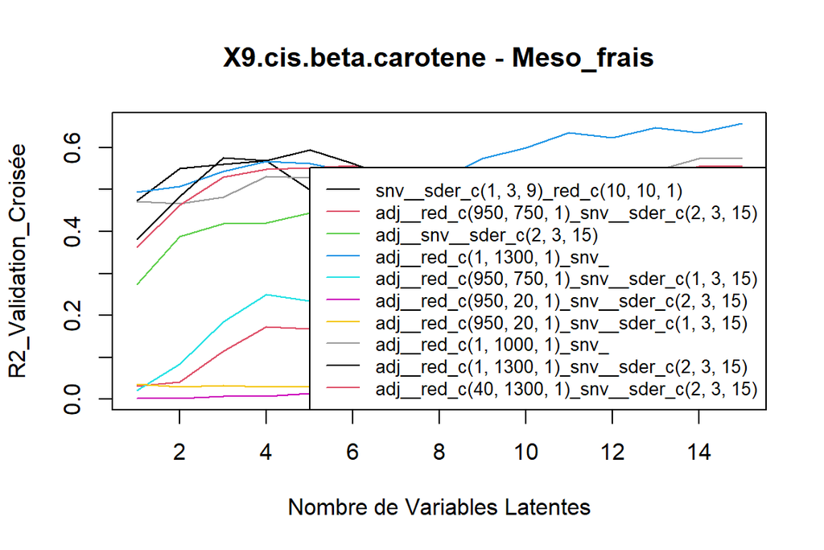

Pré : adj__red_c(1, 1300, 1)*snv*

R2 : 0.49 0.51 0.54 0.57 0.56 0.54 0.55 0.52 0.57 0.6 0.64 0.62 0.65 0.64 0.66

SEP : 51.35 50.75 48.92 47.72 48.18 49.28 48.69 50.8 47.91 46.32 44.71 45.12 43.69 44.67 43.64

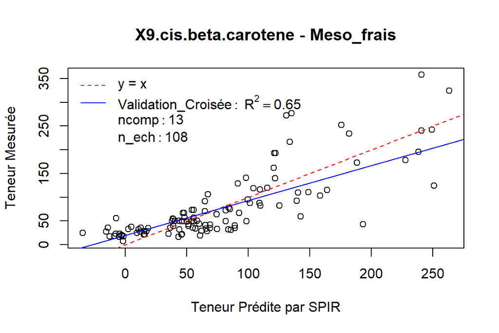

[1] “total.beta.carotenes”

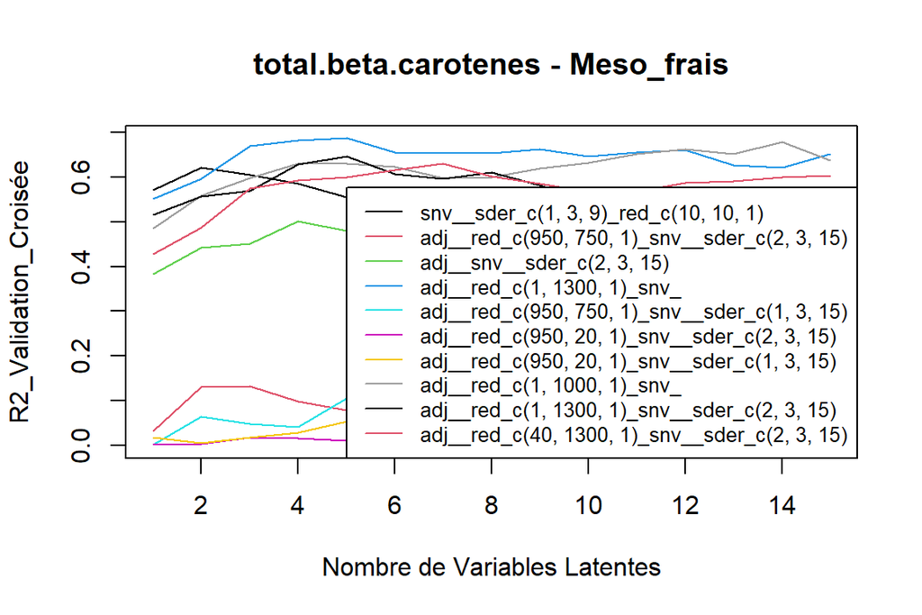

Pré : adj__red_c(1, 1300, 1)*snv*

R2 : 0.55 0.6 0.67 0.68 0.69 0.65 0.65 0.65 0.66 0.65 0.65 0.66 0.63 0.62 0.65

SEP : 297.9 283.11 256.08 251.18 249.31 264.23 264.15 263.82 261.89 266.99 264.97 266.4 280.25 285.57 272.24

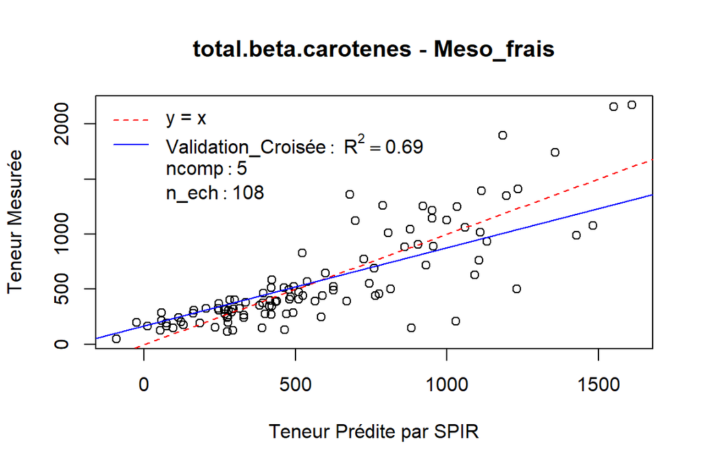

[1] “total.carotenes”

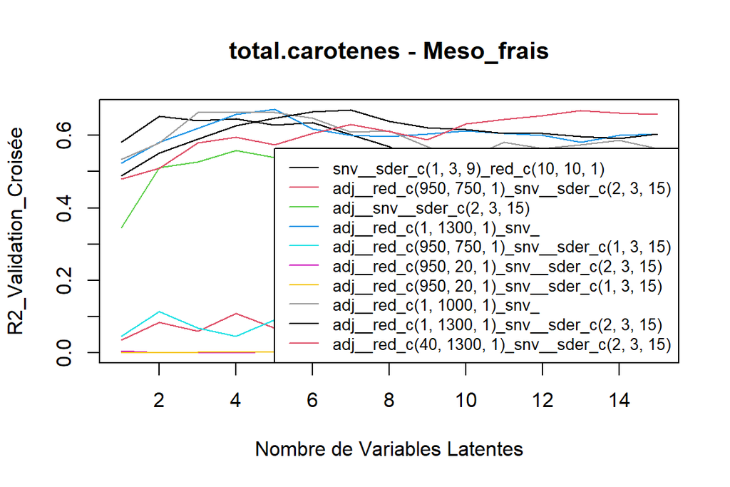

Pré : adj__red_c(1, 1300, 1)*snv*

R2 : 0.52 0.58 0.62 0.66 0.67 0.62 0.6 0.6 0.6 0.61 0.61 0.6 0.58 0.6 0.6

SEP : 522.31 489.96 467.89 443.72 434.31 475.87 486.44 491.91 487.76 487.72 487.9 487.47 505.17 499.61 497.41

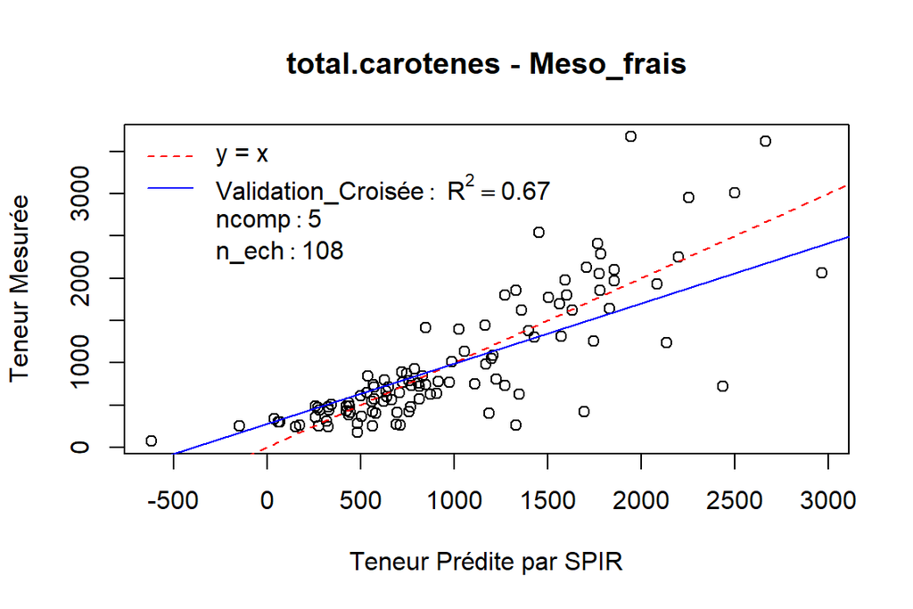